# Taller práctico - ML aplicado a Economía

Este workshop esta dirigido a personas interesadas en explorar las aplicaciones de algoritmos de Machine Learning (ML) en problemas de la vida real. Al finalizar el taller se espera que los asistentes identifiquen las oportunidades de aplicacion de tecnicas de ML en contextos interdisciplinarios, como lo es el ambito economico.

El siguiente problema fue extraido con autorizacion previa de https://www.kaggle.com/passnyc/data-science-for-good y https://www.kaggle.com/laiyipeng/target-schools-action-recommended-for-passnyc, y modificado para fines academicos.

## Resumen del problema

PASSNYC es una organización sin ánimo de lucro que se dedica a ampliar las oportunidades educativas para los estudiantes talentosos y desatendidos de la ciudad de Nueva York. Nueva York alberga algunas de las instituciones educativas mas avanzadas en el mundo; sin embargo en años recientes, las escuelas secundarias especializadas de la ciudad o Specialized High Schools (SPSH) - instituciones con un impacto historicamente transformador en los resultados estudiantiles - han visto un cambio hacia una demografía más homogénea del cuerpo estudiantil.

PASSNYC utiliza datos públicos para identificar a los estudiantes dentro de los distritos escolares de bajo rendimiento de la ciudad de Nueva York y, a través de consultas y colaboración con socios, tiene como objetivo aumentar la diversidad de estudiantes que toman el Examen de ingreso a la escuela secundaria especializado (SHSAT). Al enfocar los esfuerzos en áreas de bajo rendimiento que históricamente están subrepresentadas en el registro de SHSAT, PASSNYC ayudará a allanar el camino hacia las escuelas secundarias especializadas para un grupo más diverso de estudiantes.

PASSNYC y sus socios brindan servicios de divulgación que mejoran las posibilidades de que los estudiantes tomen el SHSAT y reciban colocaciones en estas escuelas secundarias especializadas. El proceso actual de identificación de escuelas es efectivo, pero PASSNYC podría tener un impacto aún mayor con un enfoque más informado y granular para cuantificar el potencial de divulgación en una escuela determinada.

## 1. Preprocesamiento de datos

El primer paso en la construccion de modelos de ML es el preprocesamiento de datos. Usualmente nos encontraremos con diversas fuentes de datos que contienen informacion valiosa para el modelo. Una de las ventajas de Data Science es la capacidad de manejar cantidades grandes de datos, por lo que tomaremos informacion de 7 bases de datos publicas de Nueva York para realizar nuestro modelo.

### Bases de datos a evaluar

Dividiremos las bases de datos en tres grupos: generales, demográficas y académicas.

> **Generales:**
1. Middle school directory: Directorio con todas las escuelas intermedias en NY.
2. Average class size: Tamaño promedio de las clases en todas las escuelas intermedias.
3. Pupil to teacher ratio: Ratio de # alumnos / # maestros por escuela.

> **Demográficas:**
4. School explorer: Aspectos demograficos generales de las escuelas intermedias en NY.
5. Student composition: Aspectos demograficos de las escuelas intermedias en NY, como composición demográfica (%) de cada escuela.

> **Académicas:**
6. Offers received by students in different middle schools: Numero de estudiantes que presentan el SHSAT, y estudiantes que son admitidos a una SPSH por escuela intermedia.
7. State test result: Resultados de cada escuela intermedia en las pruebas de estado realizadas de grado 5 a 8, en matematicas y ELA (English Language Arts)

## 2. ¿Qué escuelas públicas intermedias tienen más probabilidades de tener estudiantes subrepresentados en SPHS?

Las escuelas secundarias especializadas de la ciudad de Nueva York se enfrentan a críticas cada vez mayores por su falta de diversidad de género, racial y socioeconómica. En “Pathways to an Elite Education”, Corcoran y Baker-Smith usan modelos logísticos secuenciales para identificar diferencias grupales entre puntos de contacto a lo largo de la línea de aplicación de SPHS. Concluyen que cuatro grupos sociales están subrepresentados en el proceso de solicitud, admisión y matriculación: **Estudiantes afroamericanos, hispanos, mujeres y de bajos ingresos**[1]

Utilizando datos demográficos a nivel escolar, esta sección tiene como objetivo responder dos preguntas:

1. **¿Son las “escuelas representativas”, que componen la mayoría de las ofertas de SPHS, demograficamente diferentes de otras escuelas?**
2. **¿Los estudiantes de cuales escuelas públicas tienen menos probabilidades de estar representados en el proceso de solicitud?**

### 2.1 Diferencias demográficas entre escuelas representativas y no representativas

En un año típico, alrededor de 25,000 estudiantes toman el examen de admisión para las escuelas secundarias especializadas SHSAT, y solicitan admisión a alguna de las SPHS, lo que representa 1/3 del total de estudiantes en la ciudad de Nueva York. Sin embargo, las ofertas no se distribuyen equitativamente entre los estudiantes de diferentes escuelas intermedias. En 2018, las 10 mejores escuelas intermedias con la mayoría de los estudiantes admitidos en SPHS representan el 25% de las ofertas totales [2].

Para examinar si las escuelas intermedias con mayores ofertas son demográficamente diferentes de otras escuelas, se realiza la evaluacion de la distribución de tres métricas: **% de alumnas, % de estudiantes afroamericanos e hispanos, y el Índice de Necesidad Económica (ENI)**, que determina la probabilidad de que los estudiantes de la escuela esten en la pobreza (calculado como % de vivienda temporal + % de HRA elegible * 0.5 + % almuerzo gratis elegible * 0.5) [3].

De ahora en adelante, realizaremos una diferenciación entre las escuelas intermedias con mayor cantidad de estudiantes admitidos para SPHS, y los estudiantes con menor cantidad de estudiantes admitidos: - Escuelas representativas: > 5 estudiantes admitidos a SPHS - Escuelas no representativas: <= 5 estudiantes admitidos a SPHS

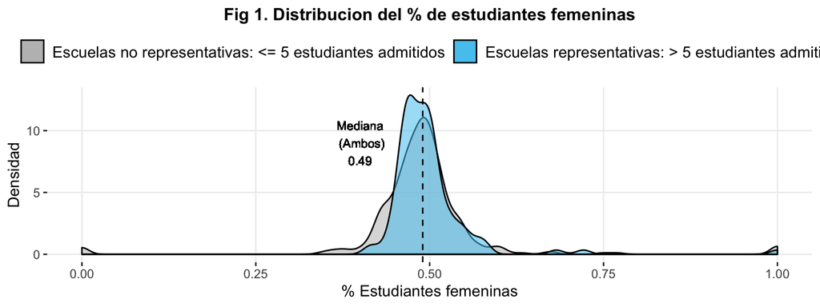

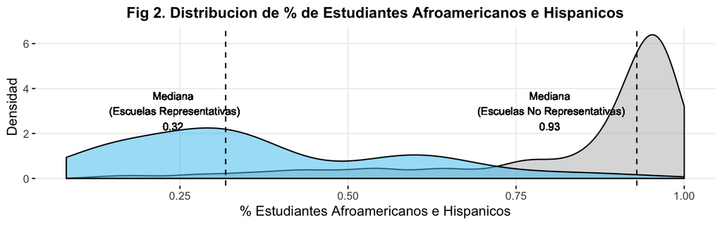

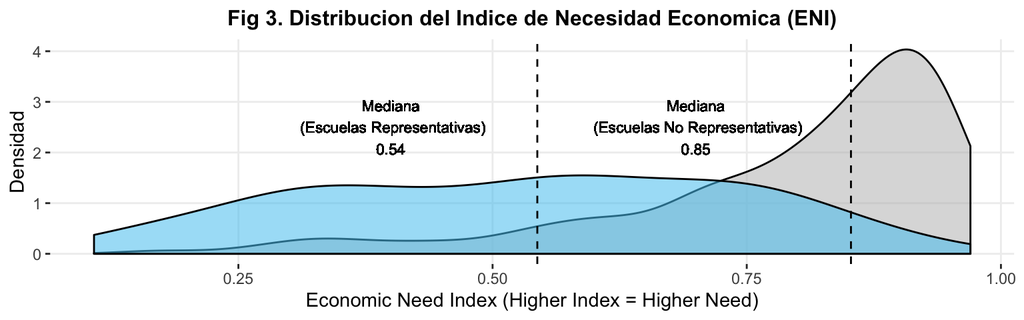

La figura 1 muestra que la proporción de género de las escuelas representativas y no representativas tiene una **distribución similar centrada en el 49% .**

Por otro lado, la Figura 2 y la Figura 3 muestran que las escuelas **representativas y no representativas son notablemente diferentes en términos de su composición racial y nivel de necesidad económica.**

En la siguiente sección, las dos últimas métricas se utilizarán para calcular un puntaje escalado para medir la probabilidad de que los estudiantes de cualquier escuela intermedia estén subrepresentados en SPHS.

### 2.2 Puntaje de subrepresentación

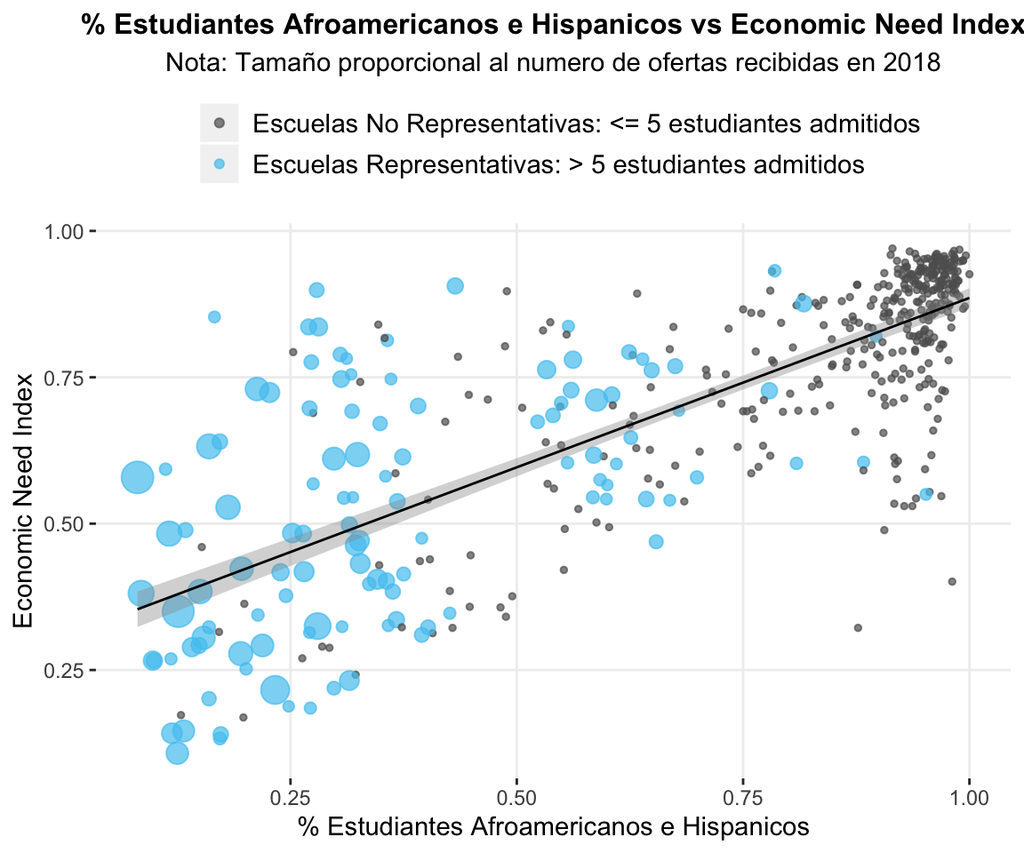

El diagrama de dispersión anterior visualiza la correlación positiva (r = 0.77, p <0.01) entre el Índice de Necesidad Económica y el % de estudiantes afroamericanos e hispanos. Las escuelas representativas con más estudiantes admitidos en SPHS (**puntos grandes azules**) tienden a tener una necesidad económica de baja a media y una menor proporción de estudiantes afroamericanos o hispanos, mientras que un notable número de escuelas no representativas (**puntos grises**) se agrupan alrededor de la esquina superior derecha del diagrama. En otras palabras, los estudiantes de estas escuelas no representativas son en su mayoría estudiantes hispanos o afroamericanos de bajos ingresos que están subrepresentados en SPHS.

Para evaluar mejor la necesidad de los estudiantes en diferentes escuelas y ayudar a PASSNYC a priorizar su esfuerzo de divulgación, se asignará a cada escuela intermedia un indicador simple, el **puntaje de subrepresentación**, para cuantificar la probabilidad de que los estudiantes de una escuela dada tengan un bajo rendimiento durante el proceso de solicitud de SPHS. Como el origen del diagrama representa una escuela intermedia sin estudiantes hispanos, afroamericanos y de bajos ingresos, **la puntuación de subrepresentación se calcula como la distancia euclidiana escalada entre un punto dado y el origen con un rango de 0 a 1 .** Un puntaje de subrepresentación cercano a 1 indica un alto nivel de subrepresentación en las SPHS.

> **Puntaje de subrepresentación = Distancia euclideana escalada entre un punto dado y el origen**

### 2.3 Escuelas Intermedias con los puntajes de subrepresentacion mas altos

Para ayudar a PASSNYC a lograr un mayor impacto, es importante identificar qué escuelas intermedias tienen menos representación en SPHS y asignar los recursos de PASSNYC en consecuencia. **Como resultado, el resto del análisis se centrará en el 25% de las escuelas intermedias con el puntaje de subrepresentación más alto, que representan 121 de 482 escuelas intermedias con datos demográficos disponibles .** Tenga en cuenta que ninguna de estas 121 escuelas tiene más de 5 estudiantes admitidos a SPHS en 2018.

La siguiente tabla enumera información sobre estas 121 escuelas clasificadas en orden descendente de su puntaje de subrepresentación.

#### Top 25% de Escuelas Intermedias con los puntajes de subrepresentación más altos

[output not shown]

| Rank | DBN (ID) | Distrito | Nombre de la Escuela | % Afroamericanos e Hispanicos | Economic Need Index | Puntaje de subrepresentacion |
| --- | --- | --- | --- | --- | --- | --- |
| 1 | 23K284 | 23 | The Gregory Jocko Jackson School of Sports, Art, and Technology (P.S./I.S. 284) | 66.2 | 0.968 | 1 |
| 2 | 10X342 | 10 | International School for Liberal Arts | 0.4 | 0.958 | 0.998 |
| 3 | 09X219 | 9 | M.S. 219 | 38.4 | 0.966 | 0.995 |
| 4 | 10X390 | 10 | M.S. 390 | 12.8 | 0.95 | 0.992 |
| 5 | 07X584 | 7 | I.S. 584 | 24.2 | 0.949 | 0.992 |
| 6 | 07X224 | 7 | Science School for Exploration and Discovery (M.S. 224) | 26.3 | 0.961 | 0.991 |
| 7 | 09X229 | 9 | Dr. Roland N. Patterson School (I.S. 229) | 39 | 0.957 | 0.99 |
| 8 | 12X211 | 12 | P.S./M.S. X211 | 13.9 | 0.948 | 0.989 |
| 9 | 09X313 | 9 | School of Leadership Development (I.S. 313) | 29.5 | 0.953 | 0.988 |
| 10 | 23K184 | 23 | The Newport School (P.S./I.S. 184) | 71.8 | 0.95 | 0.986 |

[output cut: 111 more lines]

## 3. ¿Qué escuelas intermedias públicas tienen más probabilidades de tener estudiantes calificados para SPHS?

El SPHS de la ciudad de Nueva York tiene una larga historia de apoyo a las necesidades educativas de los estudiantes con un fuerte desempeño académico o artístico. Ocho de nueve SPHS admiten estudiantes en base a un solo examen de ingreso, **SHSAT**, el cual evalúa las habilidades de los estudiantes en inglés y matemáticas. **Asumiendo que los estudiantes de las escuelas intermedias con un rendimiento académico más sólido tienen más probabilidades de estar motivados para postularse y ser admitidos en SPHS, esta sección se centrará en el rendimiento académico y tiene como objetivo responder una pregunta a través del algoritmo no supervisado k-means: ¿qué escuelas no representativas tienen calidad educativa y rendimiento académico similar al de las escuelas representativas?**

### 3.1 K-means clustering y variables utilizadas

La agrupación de K-means es un algoritmo de aprendizaje no supervisado que divide las observaciones existentes en k agrupaciones o clusters según la distancia de cada observación a la media de su cluster (wikipedia.org/wiki/k-means_clustering).

Como la sección anterior concluye que las escuelas representativas son demográficamente diferentes de las escuelas no representativas, en esta sección se implementará el algoritmo k-means para examinar las siguientes características no demográficas para identificar las escuelas no representativas que son *académicamente en lugar de demográficamente* similares a las escuelas alimentadoras .

1. Resultados de las pruebas anuales del estado de Nueva York:  
   -% de alumnos de octavo grado recibieron L1, L2, L3, L4 en las pruebas de Matemáticas y ELA (English, Language, Arts) respectivamente  
   -Puntuación de la escala promedio de las pruebas de Matemáticas y ELA
2. Revisión anual de calidad del Departamento de Educación de la Ciudad de Nueva York:  
   -Medición de instrucción rigurosa (rigorous instruction)  
   -Medición de profesores colaborativos (collaborative teachers)  
   -Medición del entorno de apoyo (supportive environment)  
   -Medición del liderazgo escolar efectivo (effective school leadership)  
   -Medición de fuertes lazos familiares y comunitarios (strong family community ties)  
   -Medición de confianza (trust)
3. Otros:  
   -Tasa promedio de asistencia estudiantil (Average student attendance rate)  
   -Tasa promedio de ausencia crónica (Average chronical absence rate)
- Proporción de alumnos por maestro (Pupil to teacher ratio)  
  -Tamaño de clase promedio (Average class size)

### 3.2 K-Means Clusters

El método de codo (elbow method) determina que el número óptimo de clusters es 3.

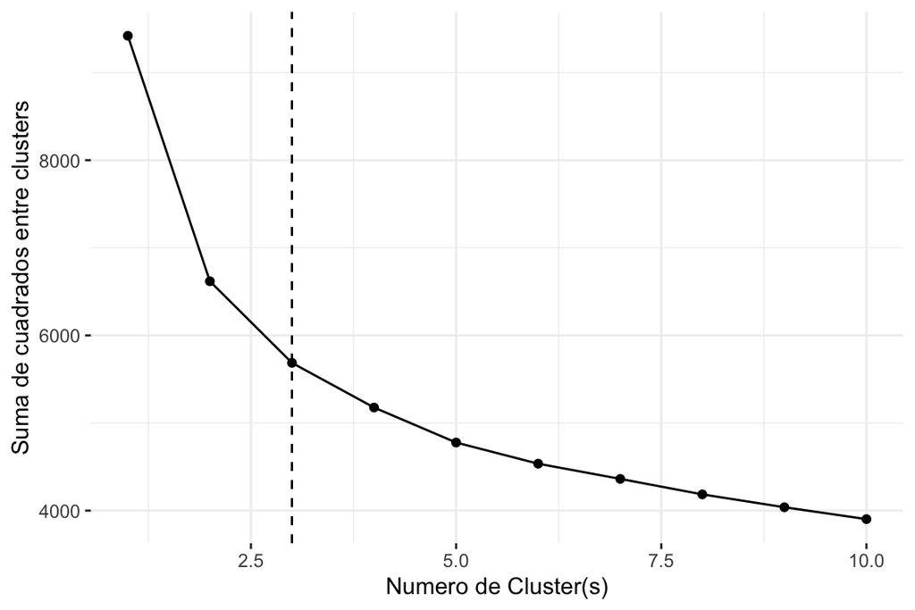

Usando las 20 características enumeradas anteriormente, el algoritmo k-means divide 472 escuelas intermedias con datos disponibles en 3 grupos con diferentes niveles de rendimiento académico como se muestra en el siguiente diagrama de dispersión.

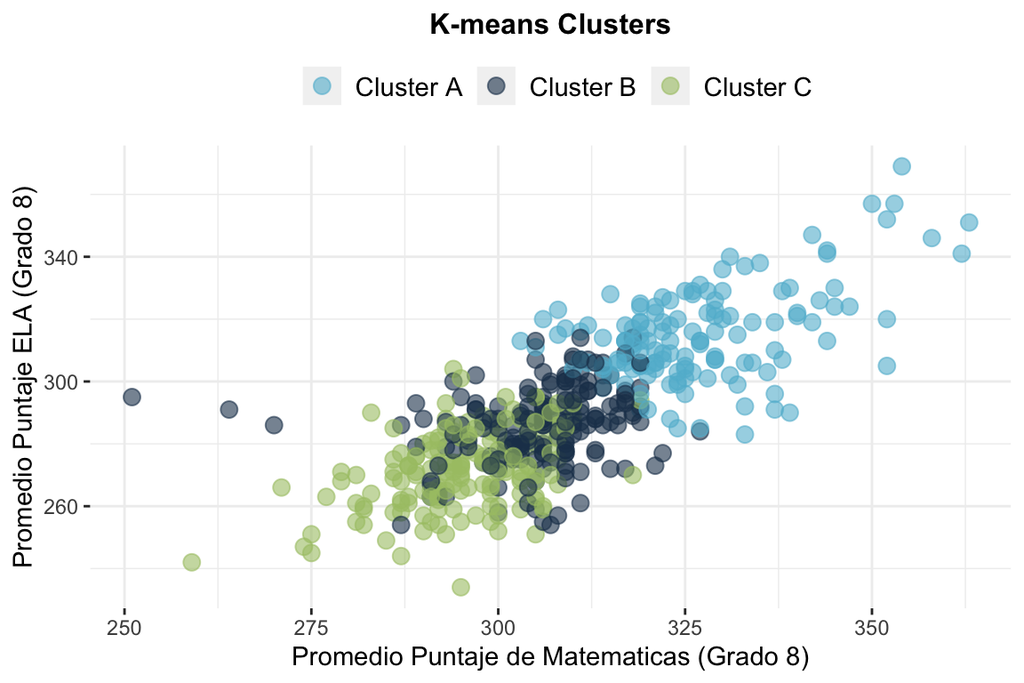

[output not shown]

Entre los clusters identificados, más del 60% de las escuelas intermedias en el Grupo A son escuelas secundarias con más de 5 estudiantes aceptados por SPHS en 2018. El Grupo A también tiene las puntuaciones medias más altas en los exámenes estatales de ELA y Matemáticas, dos de los predictores más fuertes para Rendimiento de los estudiantes en SHSAT [1]. Como cada escuela intermedia con datos disponibles ha sido asignada a un grupo basado en características no demográficas, la etiqueta del grupo se usará para inferir la probabilidad de que una escuela intermedia determinada tenga estudiantes calificados para SPHS:

> **Cluster A**: Alta probabilidad de tener estudiantes calificados para SPHS  
> **Cluster B**: Probabilidad media de tener estudiantes calificados para SPHS  
> **Cluster C**: Baja probabilidad de tener estudiantes calificados para SPHS

## 4. Recomendaciones a PASSNYC

De todas las escuelas intermedias en el cuartil superior (ver sección 2.3) del puntaje de subrepresentación, 119 escuelas intermedias tienen datos disponibles y, por lo tanto, se asignan a uno de los tres clusters de k-means como se muestra en los siguientes diagramas. __ De 119 escuelas, 53 están asignadas al Cluser A y B, lo que indica un alto nivel de calidad educativa y potencial académico. Los estudiantes de estas escuelas intermedias tienen más probabilidades de estar calificados y, por lo tanto, estar motivados para solicitar SPHS, y deben tener mayor prioridad en el esfuerzo de extensión de PASSNYC.

#### K-means Clusters para el Top 25% de Escuelas Intermedisas con el Puntaje de Subrepresentación más alto

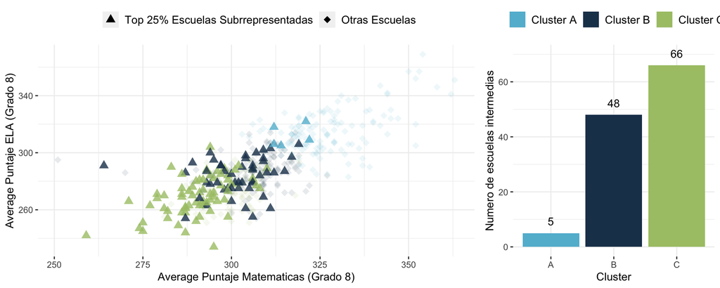

### 4.1 Recomendacion 1: Intervencion en el campus para 5 escuelas en el Cluster A

Como se presentó en la Sección 3, el Cluster A representa las escuelas intermedias que tienen más probabilidades de tener estudiantes calificados para SPHS. De todas las escuelas intermedias en el cuartil superior del puntaje de subrepresentación, 5 escuelas están asignadas al Grupo A, pero ninguna de ellas tiene más de 5 estudiantes aceptados por SPHS en 2018. Es probable que los estudiantes de estas escuelas se beneficien más de servicios proporcionados por PASSNYC y sus socios, y estas escuelas deben tener la máxima prioridad en el plan de PASSNYC. Como resultado, se recomienda la intervención en el campus en estas escuelas intermedias.

5 Escuelas Subrrepresentadas en Cluster A

| DBN | Distrito | Nombre de la Escuela | Score de diversidad | Avg Puntaje ELA | Avg Puntaje Matematicas |
| --- | --- | --- | --- | --- | --- |
| 07X223 | 7 | The Laboratory School of Finance and Technology: X223 | 0.97 | 312 | 318 |
| 09X327 | 9 | Comprehensive Model School Project (M.S. 327) | 0.95 | 321 | 322 |
| 09X128 | 9 | Mott Hall III | 0.94 | 312 | 306 |
| 10X015 | 10 | The Institute for Environmental Learning (P.S. 15) | 0.94 | 322 | 309 |
| 10X308 | 10 | Bronx Dance Academy | 0.94 | 314 | 305 |

### 4.2 Recomendación 2: Campaña de sensibilización en 48 escuelas del Grupo B

Se recomienda a PASSNYC lanzar una campaña de sensibilización en 48 escuelas en el Cluster B mediante la distribución de volantes informativos o el envío de correos físicos o correos electrónicos a maestros, padres y estudiantes. Con esto se lograría aumentar la conciencia sobre SHSAT y SPHS en 48 escuelas intermedias en el Grupo B.

48 Escuelas Subrrepresentadas en Cluster B

| DBN | Distrito | Nombre de la Escuela | Score de diversidad | Avg Puntaje ELA | Avg Puntaje Matematicas |
| --- | --- | --- | --- | --- | --- |
| 10X342 | 10 | International School for Liberal Arts | 1 | 300 | 285 |
| 06M349 | 6 | Harbor Heights Middle School | 0.98 | 264 | 291 |
| 10X206 | 10 | Ann Mersereau (M.S. 206) | 0.98 | 294 | 278 |
| 32K349 | 32 | Math, Science &amp; Technology (I.S. 349) | 0.98 | 298 | 287 |
| 07X005 | 7 | Port Morris (P.S./M.S. 5) | 0.97 | 306 | 289 |
| 07X343 | 7 | Academy of Applied Mathematics &amp; Technology | 0.97 | 317 | 297 |
| 01M188 | 1 | The Island School (P.S. 188) | 0.97 | 287 | 286 |
| 12X212 | 12 | P.S./M.S 212 | 0.97 | 294 | 300 |
| 12X341 | 12 | ACCION Academy | 0.97 | 315 | 287 |
| 19K663 | 19 | School of the Future Brooklyn | 0.97 | 287 | 254 |

[output cut: 38 more lines]

## 5. Referencias:

[1] Sean Patrick Corcoran & E. Christine Baker-Smith, “Pathways to an Elite Education: Application, Admission, and Matriculation to New York City’s Specialized High Schools”  
[2] Jennifer Medina, New York Times, “A Demographic Breakdown of Who Took, and Passed, the Test” https://cityroom.blogs.nytimes.com/2010/02/16/a-demographic-breakdown-of-who-took-and-passed-the-test/ [3] Equity and Excellence for All: Diversity in New York City Public Schools https://www.schools.nyc.gov/docs/default-source/default-document-library/diversity-in-new-york-city-public-schools-english